# scRNAseq Interstitial cells : What happens over time?

Marion Hardy

2024-02-29

# Introduction

Data from our collaborator Panagiotis rds file for a SingleCellExperiment object containing the single cell data for **the interstitial cells** of *Hydra Vulgaris* during multiples stages of regeneration after bisection:

https://www.dropbox.com/scl/fi/dg76sigjnj5u6qr06xk79/sce_interstitial_Juliano.rds?rlkey=f0y3lqt0wdcwq652zisnrpf9t&dl=0

BUT they mapped it to *Hydra Magnipapillata (102)* “Drop-seq reads from 15 libraries generated for Hydra vulgaris strain AEP were mapped to the 2.0 genome assembly of closely related Hydra vulgaris strain 102 (available at https://research.nhgri.nih.gov/hydra/) and processed using the Hydra 2.0 gene models. Strain Hydra vulgaris 102 was formerly referred to as Hydra magnipapillata.”

The coldata of the object contain cell annotation including

- quality metrics: nFeature nCount (not MT percentage interestingly)
- batch info: either 2869 (3162 barcodes), 3113 (10352 barcodes), 3271 (13279 barcodes), 3357 (3875 barcodes)
- originating experiments (head or foot regeneration)
- experimental time points
- pseudo-axis assignment (vals.axis ranging from 0-1, increasing in the foot-tentacle direction)
- mitotic and apoptotic signatures indices from 0 to 1

The rowdata contains gene annotation, using Entrez-gene identifiers. I have also noticed that in the sce objects there’s

- PCA, tSNE and UMAP coordinates for reduced dimensions + corrected for batch values
- assay metafeatures hold gene_id, product, gene, is.rib.prot.gene (T/F), HypoMarkers (T/F), ccyle (T/F), apopt (T/F) etc

I converted the sce objects 6.6gb into a seurat object 2.2 gb and checked that all cited parameters could be found in it.

# Summary of 2/28 meeting with Hannah and Celina

- REG_FOOT = It’s a head that is regenerating a foot (counterintuitive)
- Clusters have been attributed with confidence except 10 which is likely doublets but should be explored further
- Cluster 5 are probably glands but I haven’t found a characterized marker I could use with the Hydra atlas
- Blast transcription factors with the g id !
- Do population number evolution over time (not just neurons!)
- Cluster with 0.1 resolution
- Aligning to the 105 genome

# Data loading and upate on the project

In this report we’re gonna plot transcription factors of interest over the different timepoints. I also wanted to add cell population counts over time. Maybe I could learn to plot gene expression over time too?= Anyway, we’re exploring gene expression programs and cell populations over time.

## Changing UMAP resolution

```
## Modularity Optimizer version 1.3.0 by Ludo Waltman and Nees Jan van Eck
##
## Number of nodes: 29280
## Number of edges: 889358
##
## Running Louvain algorithm...
## Maximum modularity in 10 random starts: 0.9832
## Number of communities: 21
## Elapsed time: 2 seconds
```

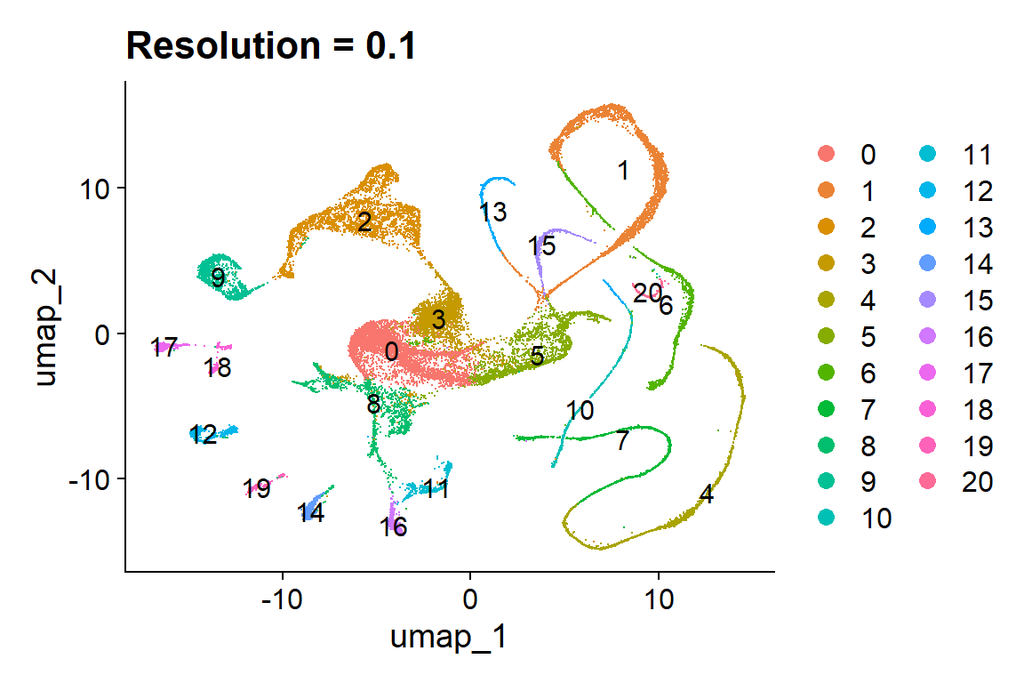

```r
target <- c("NSP4","midasin","mini-COL8","SP-D-like","FH20-X3","CAII",
            "CELA3B","zinc-carboxypeptidase","ANO39","TYN1","H2A.2.2","nas2-X2",
            "Lwamide-X1","DMRT1","TUBA4A-X1","HTRA3","polRF-X1","ec3A","ec3B",
            "nop58-X1","OTP","MEP1A","rhammosyl-O-methyltransferase","hywnt3",
            "PPOD1","ks1","hyAlx","ELAV2","POU4","MUC2", "ec3", "grm1","myc",
            "myc1","wnt3","ec2","ec1B","ec4","ec1A","en1","en1_NDF1_DANRE",
            "ec5","en1","en2A","en2B")
```

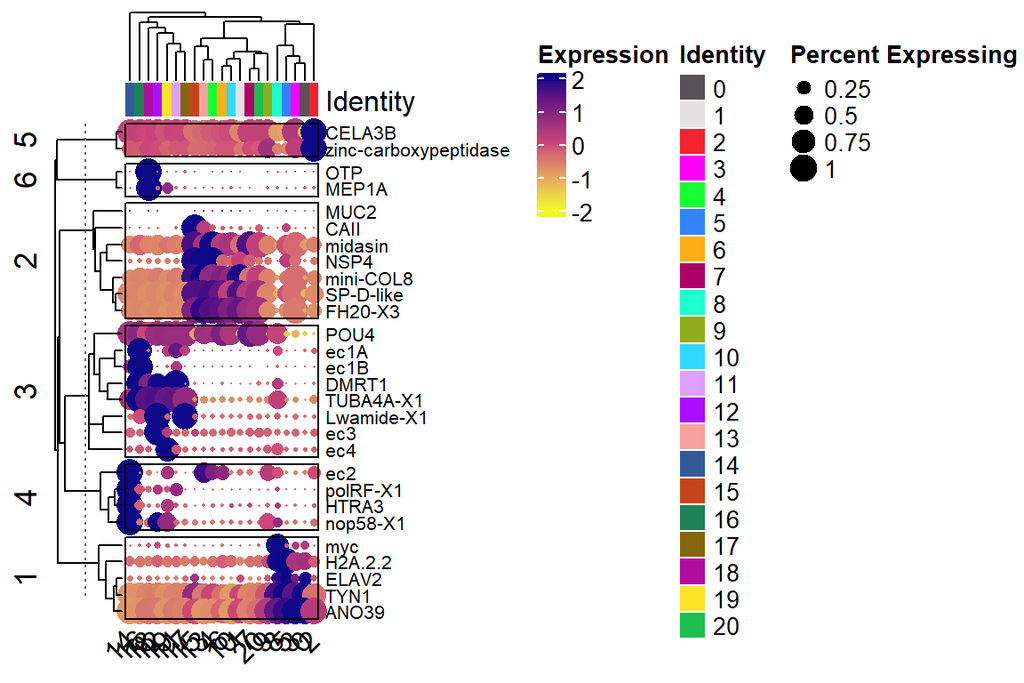

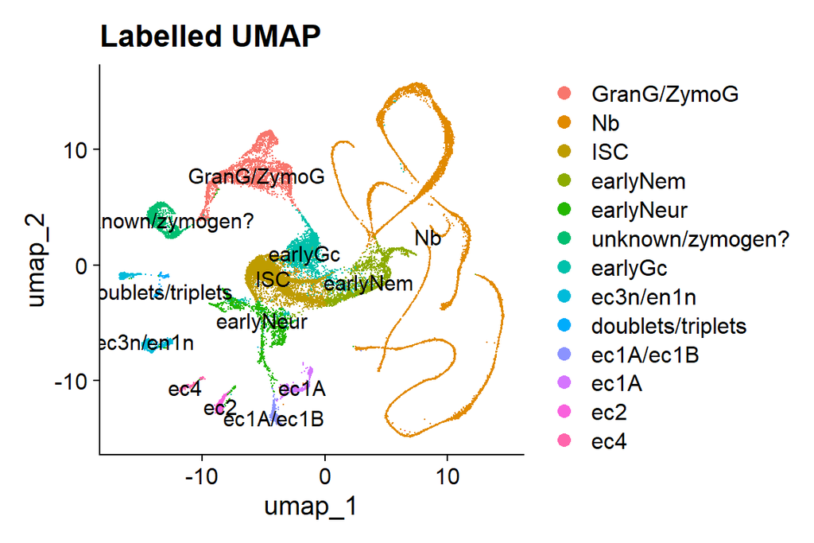

## Subsetting by head/foot and timepoint

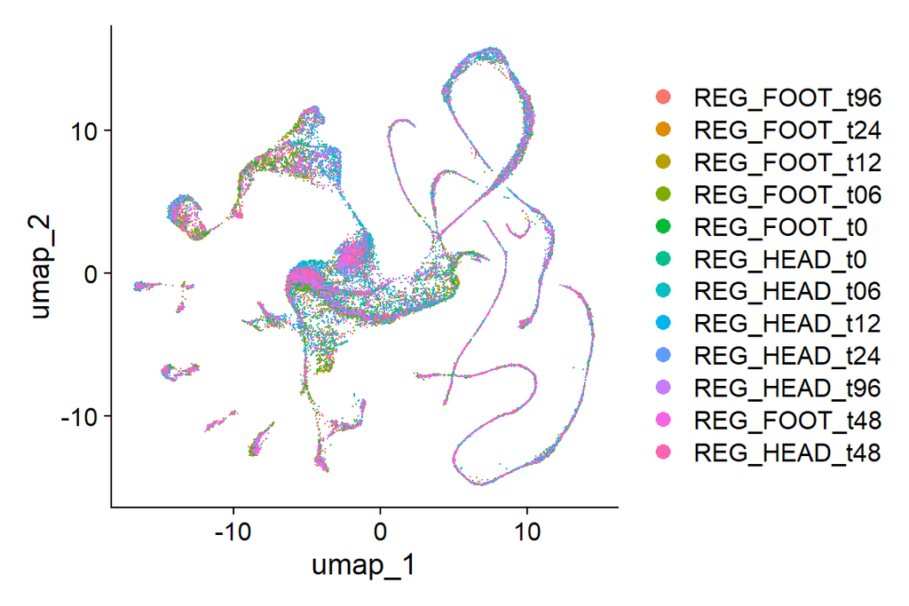

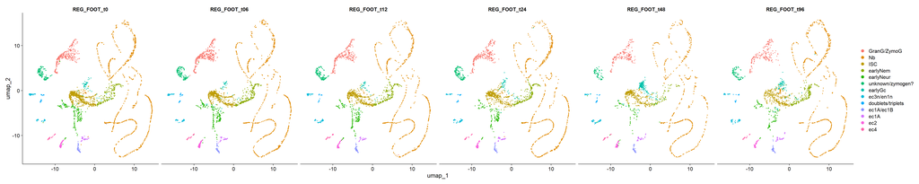

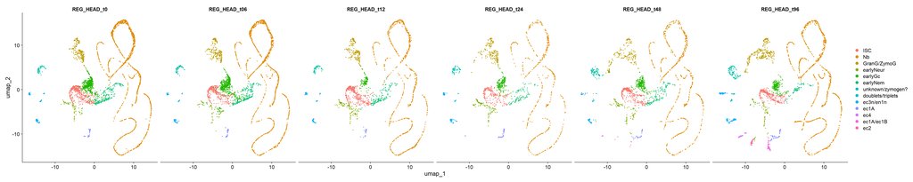

## Cell population evolution over time

### Regenerating a head

|  | REG_HEAD_t0 | REG_HEAD_t06 | REG_HEAD_t12 | REG_HEAD_t24 | REG_HEAD_t48 | REG_HEAD_t96 |
| --- | --- | --- | --- | --- | --- | --- |
| doublets/triplets | 36 | 27 | 29 | 18 | 24 | 56 |
| earlyGc | 684 | 574 | 129 | 208 | 278 | 253 |
| earlyNem | 202 | 209 | 148 | 84 | 128 | 78 |
| earlyNeur | 59 | 65 | 125 | 96 | 102 | 78 |
| ec1A | 67 | 55 | 48 | 64 | 50 | 112 |
| ec1A/ec1B | 0 | 0 | 0 | 0 | 3 | 58 |
| ec2 | 0 | 0 | 0 | 0 | 1 | 56 |
| ec3n/en1n | 76 | 64 | 71 | 80 | 65 | 168 |
| ec4 | 0 | 0 | 0 | 2 | 6 | 71 |
| GranG/ZymoG | 256 | 246 | 204 | 212 | 223 | 320 |
| ISC | 488 | 388 | 420 | 201 | 339 | 384 |
| Nb | 1549 | 1398 | 870 | 553 | 737 | 1288 |
| unknown/zymogen? | 64 | 73 | 66 | 60 | 95 | 115 |
| Sum | 3481 | 3099 | 2110 | 1578 | 2051 | 3037 |

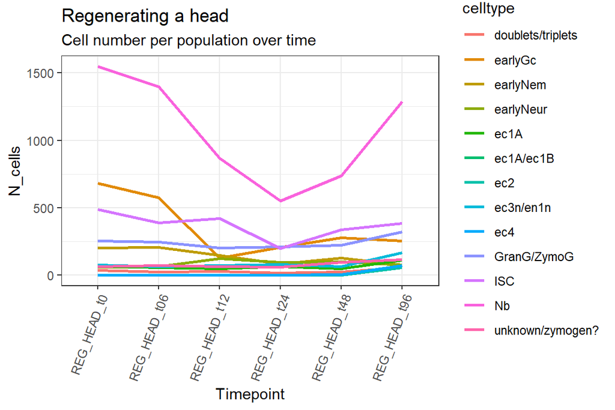

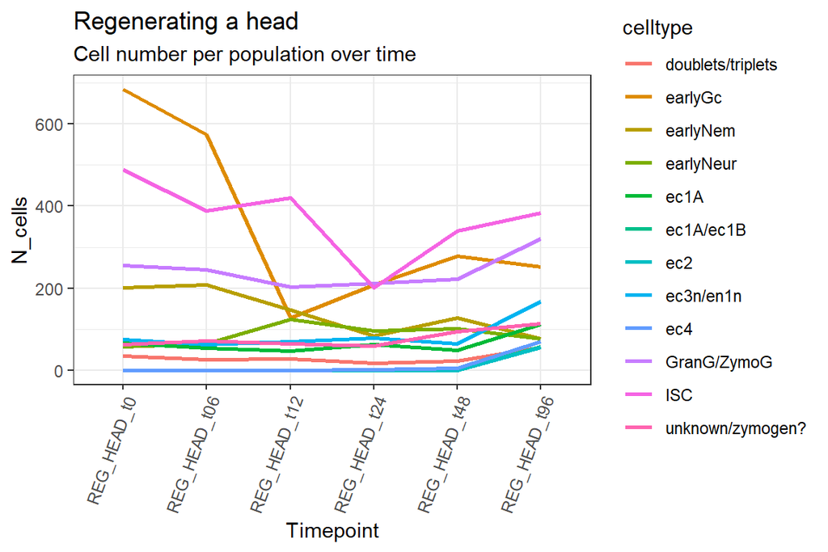

### Regenerating a foot

|  | REG_FOOT_t0 | REG_FOOT_t06 | REG_FOOT_t12 | REG_FOOT_t24 | REG_FOOT_t48 | REG_FOOT_t96 |
| --- | --- | --- | --- | --- | --- | --- |
| doublets/triplets | 38 | 31 | 28 | 22 | 27 | 19 |
| earlyGc | 60 | 41 | 38 | 51 | 204 | 85 |
| earlyNem | 200 | 266 | 211 | 236 | 86 | 205 |
| earlyNeur | 199 | 201 | 176 | 143 | 66 | 100 |
| ec1A | 51 | 57 | 42 | 54 | 36 | 55 |
| ec1A/ec1B | 59 | 77 | 58 | 51 | 64 | 55 |
| ec2 | 80 | 103 | 77 | 63 | 84 | 51 |
| ec3n/en1n | 91 | 87 | 94 | 75 | 56 | 68 |
| ec4 | 49 | 48 | 46 | 43 | 43 | 32 |
| GranG/ZymoG | 332 | 374 | 280 | 269 | 189 | 196 |
| ISC | 581 | 452 | 401 | 390 | 320 | 287 |
| Nb | 948 | 790 | 731 | 797 | 559 | 713 |
| unknown/zymogen? | 149 | 152 | 143 | 131 | 65 | 93 |
| Sum | 2837 | 2679 | 2325 | 2325 | 1799 | 1959 |

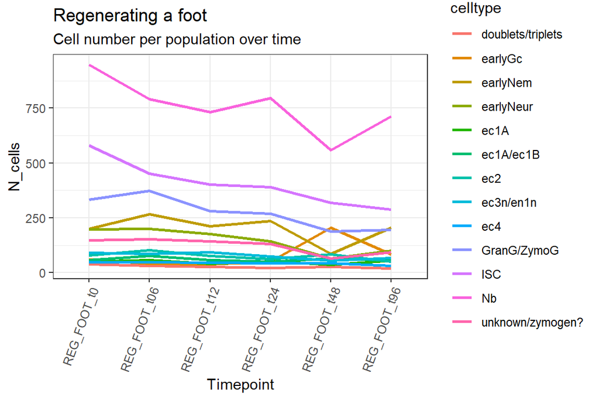

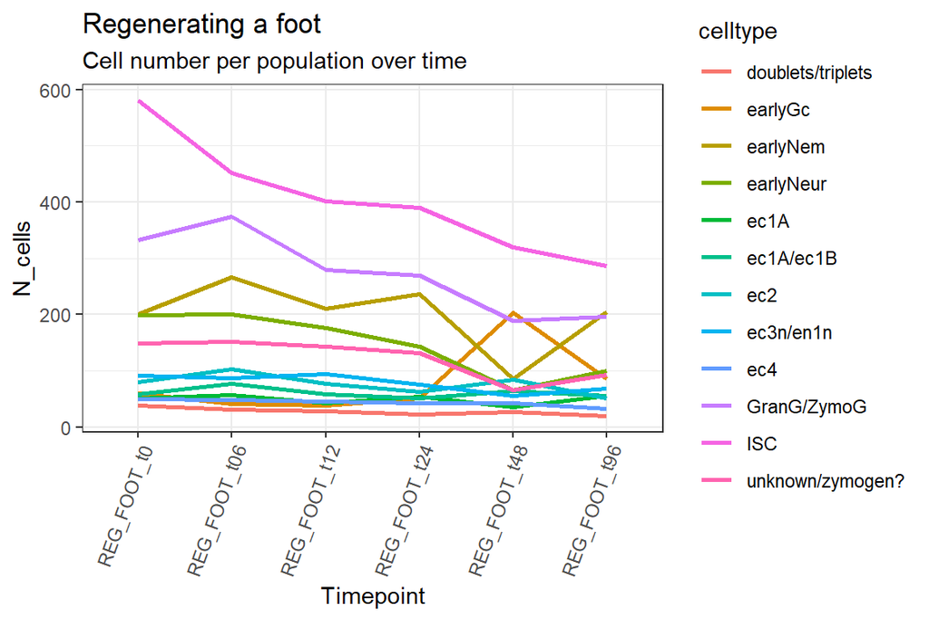

## Transcription factors

### Feature plot

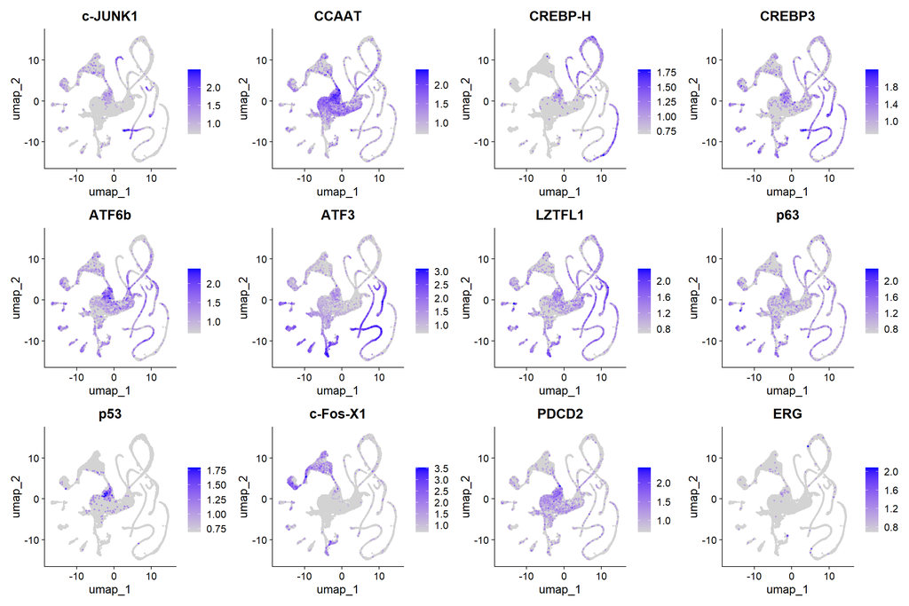

### Clustered dotplot

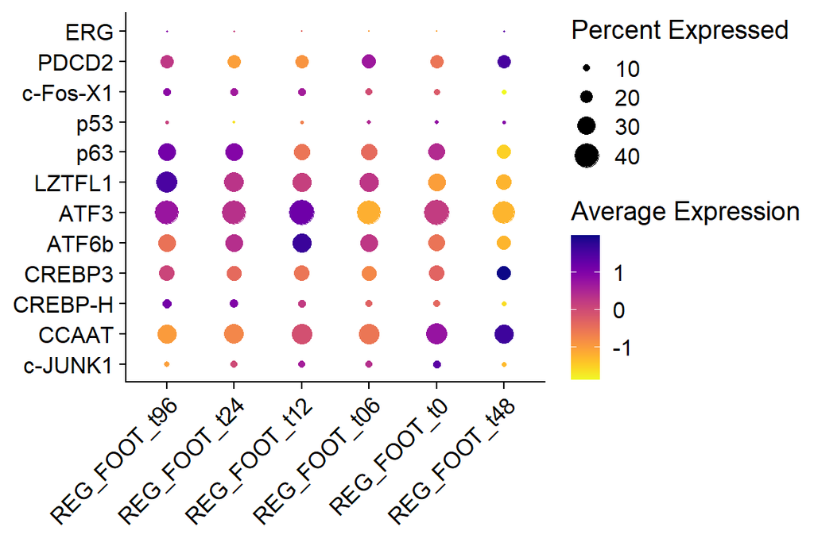

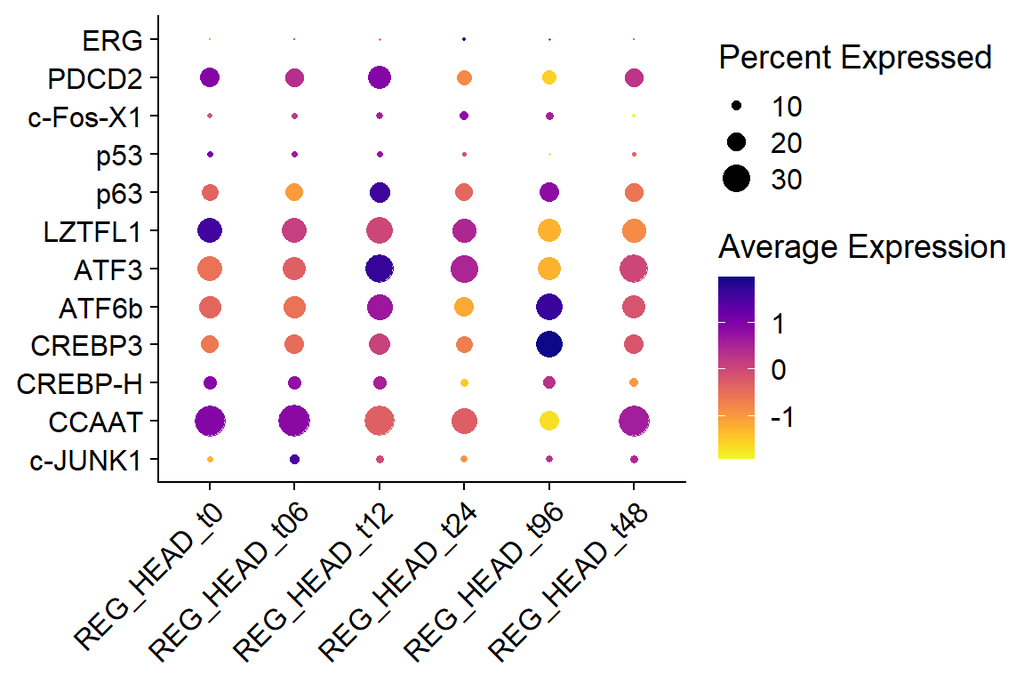